# Digital Marketing Campaign Performance Analysis Uncovering What Drives ROI, Identifying Wasted Spend, and Timing the Perfect Q4 Campaign Push

# Business Objective

A digital marketing team running campaigns across four channels — Social, Search, Email, and Display — needed answers to three critical questions their dashboard wasn't telling them:

- Which channels are actually generating returns, and which are consuming budget without proportional results?
- Which audience segments convert best, and are we spending enough to reach them?
- Is our Q4 revenue spike something we created with more spend — or organic seasonal demand we could be capitalizing on more?

Without answers, the team risks over-investing in underperforming channels, under-investing in high-efficiency ones, and missing the optimal window to push Q4 budget for maximum return.

# What This Analysis Delivers

This analysis applies a full three-layer analytical framework across 12 months of campaign data, 4 channels, and 3 audience segments to produce data-backed budget allocation and campaign timing recommendations.

**What → Why → So What**

- **Descriptive** — maps the performance landscape across channels, segments, and months
- **Diagnostic** — identifies the root causes behind ROI gaps, seasonal patterns, and segment inefficiencies
- **Prescriptive** — delivers specific channel budget recommendations and an optimized Q4 campaign brief

## Dataset Overview

- 300 campaigns · 12 months · 4 channels · 3 audience segments
- 12 variables including spend, revenue, impressions, clicks, conversions, CTR, conversion rate, and ROI

## Tools Used

Python · Pandas · NumPy · Matplotlib · Seaborn · Jupyter Notebook

## Analyst

**CJ John Paulin**  
Freelance Data Analyst  
linkedin.com/in/cjjohnpaulin · github.com/cjjohnpaulin

# Exploratory Data Analysis(EDA)

|  | CAMPAIGN_ID | MONTH | IMPRESSIONS | CLICKS | CONVERSIONS | SPEND | REVENUE | CTR | CONVERSION_RATE | ROI | cost_per_conversion |
| --- | --- | --- | --- | --- | --- | --- | --- | --- | --- | --- | --- |
| count | 300.000 | 300.000 | 300.000 | 300.000 | 300.000 | 300.000 | 300.000 | 300.000 | 300.000 | 300.000 | 300.000 |
| mean | 150.500 | 6.500 | 568459.630 | 28356.260 | 1258.250 | 8451.239 | 333655.749 | 0.043 | 0.038 | 27.115 | 32.559 |
| std | 86.747 | 3.458 | 353356.931 | 30926.773 | 1870.017 | 4171.167 | 726881.176 | 0.023 | 0.018 | 38.443 | 64.158 |
| min | 1.000 | 1.000 | 122804.000 | 967.000 | 7.000 | 1832.650 | 989.210 | 0.005 | 0.005 | -0.793 | 1.287 |
| 25% | 75.750 | 3.750 | 328590.000 | 7266.750 | 226.500 | 5537.272 | 35143.392 | 0.022 | 0.025 | 5.227 | 6.057 |
| 50% | 150.500 | 6.500 | 476787.000 | 16928.000 | 620.500 | 7734.535 | 97571.260 | 0.044 | 0.035 | 12.904 | 10.775 |
| 75% | 225.250 | 9.250 | 729110.250 | 37045.500 | 1439.750 | 10712.892 | 281487.068 | 0.060 | 0.048 | 32.644 | 31.014 |
| max | 300.000 | 12.000 | 2325256.000 | 194391.000 | 12908.000 | 24370.250 | 6951384.930 | 0.103 | 0.090 | 284.241 | 666.416 |

```
<class 'pandas.core.frame.DataFrame'>
RangeIndex: 300 entries, 0 to 299
Data columns (total 12 columns):
 #   Column            Non-Null Count  Dtype
---  ------            --------------  -----
 0   CAMPAIGN_ID       300 non-null    int64
 1   MONTH             300 non-null    int64
 2   CHANNEL           300 non-null    string
 3   AUDIENCE_SEGMENT  300 non-null    string
 4   IMPRESSIONS       300 non-null    int64
 5   CLICKS            300 non-null    int64
 6   CONVERSIONS       300 non-null    int64
 7   SPEND             300 non-null    float64
 8   REVENUE           300 non-null    float64
 9   CTR               300 non-null    float64
 10  CONVERSION_RATE   300 non-null    float64
 11  ROI               300 non-null    float64
dtypes: float64(5), int64(5), string(2)
memory usage: 28.3 KB
```

```
Duplicate rows : 0
Null values :
 CAMPAIGN_ID         0
MONTH               0
CHANNEL             0
AUDIENCE_SEGMENT    0
IMPRESSIONS         0
CLICKS              0
CONVERSIONS         0
SPEND               0
REVENUE             0
CTR                 0
CONVERSION_RATE     0
ROI                 0
dtype: int64
```

# Dataset Variables

**campaign_id**:unique identifier

**channel**:Social / Search / Email / Display

**audience_segment**:Young Adults / Professionals / Seniors

**month**:Jan–Dec 2023

**impressions**:total ad views

**clicks**:total link clicks

**conversions**:completed purchases

**spend**:USD campaign cost

**revenue**:USD revenue generated

**ctr**:click-through rate %

**conversion_rate**:conversions / clicks %

**roi**:(revenue - spend) / spend

## First 5 rows of dataset

|  | CAMPAIGN_ID | MONTH | CHANNEL | AUDIENCE_SEGMENT | IMPRESSIONS | CLICKS | CONVERSIONS | SPEND | REVENUE | CTR | CONVERSION_RATE | ROI |
| --- | --- | --- | --- | --- | --- | --- | --- | --- | --- | --- | --- | --- |
| 0 | 1 | 1 | Email | Young Adults | 560816 | 22881 | 1064 | 4909.61 | 132608.36 | 0.0408 | 0.0465 | 26.0100 |
| 1 | 121 | 1 | Display | Professionals | 790824 | 9569 | 291 | 7552.21 | 105365.96 | 0.0121 | 0.0304 | 12.9517 |
| 2 | 265 | 1 | Email | Professionals | 734651 | 27917 | 1921 | 5989.99 | 736243.41 | 0.0380 | 0.0688 | 121.9123 |
| 3 | 169 | 1 | Email | Professionals | 271380 | 10122 | 835 | 5974.90 | 297316.61 | 0.0373 | 0.0825 | 48.7609 |
| 4 | 37 | 1 | Display | Seniors | 136365 | 1650 | 15 | 3134.73 | 1120.59 | 0.0121 | 0.0091 | -0.6425 |

# Descriptive — what happened?

## 1. What is the overall distribution of ROI, spend, and revenue across all campaigns?

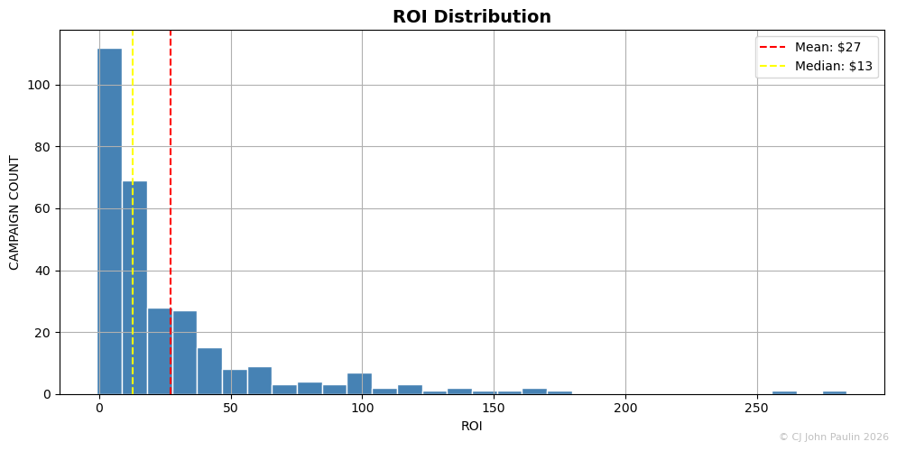

#### Data Shows that across 300 campaign, average roi was `$27` and median roi was `$13`.

#### This means high performing ROI campaign pull the average up.

#### There are about 110 campaign that has an roi around `$10`. About 70 campaign has ROI of around `$13`. About 30 campaign has an RoI of around `$25`. About 30 campaign has ROI of around `$35`.

#### This means that few campaigns have high roi , and many campaigns have low roi

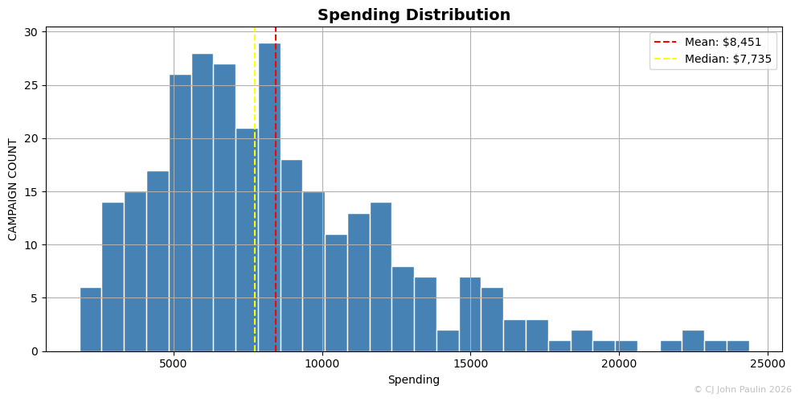

#### Data show that across 300 campaign, Average Spending was `$8,451` and Median spending was `$7,735`.This means there are campaigns that has higher spending.

#### Data shows that about 137 campaigns (46%) was in the range of having spending spending around `$5000` to `$9000`.

#### About 26 campaigns (8.6%) have spending exceeding `$15000`.

#### This means there are some campaign that have very high spending.And most campaigns have been around average spending.

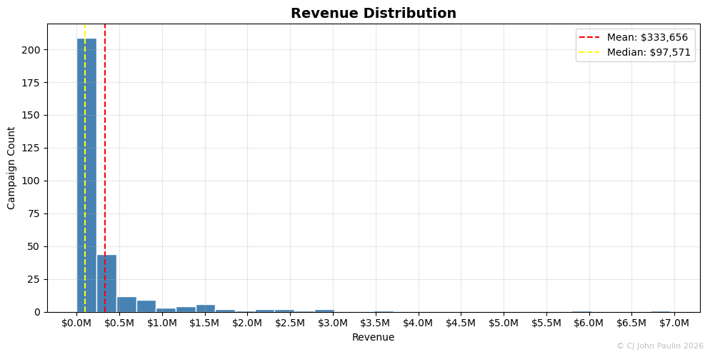

### Data shows that about 216 campaigns has revenue less than `$250,000` . About 24 campaigns has revenue exceeding 1 million dollars . About 2 campaigns has revenue exceeding 5 million dollars.

#### This means many campaign belongs to lower revenue and less campaigns belong to high revenue.

## 2. Which channel generates the highest average ROI and revenue?

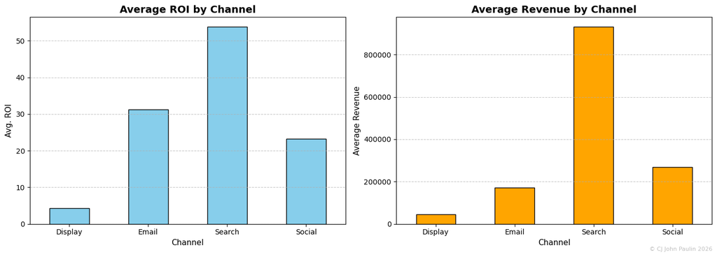

### This means Search Channel is the highest Roi genearator thus it performs best, then the Email and Social Channel is only around half of what Search roi can generate.While Display Channel performs very poor across the poor

### Data shows a wide gap of Search Channel having avg revenue around `$930k` , followed by Social around `$267k`, then Email channel at around `$172k` and Display at around`$46k` average.

#### This means Search performs outstanding in terms of averge revenue, display Channel performs very poor, then Email and Social barely generates average revenue to have fair performance.

## 3. Which audience segment converts best — and which costs the most to reach?

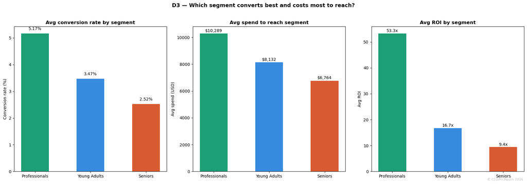

```
 -Segment Performance Summary-


                  avg_conversion_rate  avg_spend  avg_revenue  avg_roi  \
AUDIENCE_SEGMENT
Professionals                  0.0517   10289.40    723880.52  53.2802
Seniors                        0.0252    6763.77     77485.67   9.4183
Young Adults                   0.0347    8132.16    171857.83  16.7453

                  total_campaigns
AUDIENCE_SEGMENT
Professionals                 104
Seniors                        94
Young Adults                  102

-Cost Per Conversion by Segment-
AUDIENCE_SEGMENT
Professionals    20.09
Young Adults     35.75
Seniors          42.89
Name: cost_per_conversion, dtype: float64
```

### Data shows we have average spending more on campaign for Proffesionals(`$10,000`) , followed by Young adults at around (`$8,000`) then Senior audience average spnding at around (`$ 6,500`).

### IT shows that average spending and conversion have same rank order for the 3 audience.

### Seniors had the highest cost conversion( 42.89) by segment, followed by Young Adults (35.75) then Professional(20.09).Cost per conversion is how much we spend to acquire one actual customer who completed a purchase.

## 4. How did total monthly spend and revenue trend across the 12 months?

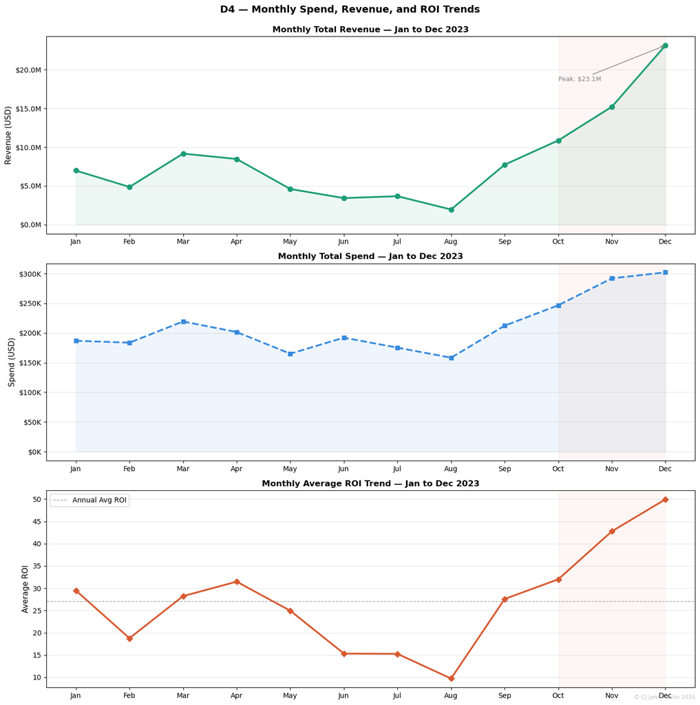

```
________________________________________________________________________
MONTHLY PERFORMANCE SUMMARY
________________________________________________________________________
Month Total Spend Total Revenue Avg ROI Rev/Spend Ratio
  Jan    $186,866        $6.98M    29.5          37.36x
  Feb    $183,643        $4.87M    18.8          26.50x
  Mar    $219,336        $9.17M    28.2          41.79x
  Apr    $201,583        $8.47M    31.5          42.03x
  May    $165,025        $4.60M    24.9          27.88x
  Jun    $192,126        $3.43M    15.3          17.85x
  Jul    $175,217        $3.67M    15.2          20.97x
  Aug    $158,327        $1.96M     9.7          12.37x
  Sep    $212,277        $7.74M    27.6          36.46x
  Oct    $246,669       $10.87M    32.0          44.06x
  Nov    $292,123       $15.22M    42.8          52.09x
  Dec    $302,178       $23.13M    50.0          76.53x

________________________________________________________________________
TOP 3 MONTHS BY REVENUE
________________________________________________________________________
Month Revenue Avg ROI
  Dec $23.13M    50.0
  Nov $15.22M    42.8
  Oct $10.87M    32.0

________________________________________________________________________
BOTTOM 3 MONTHS BY REVENUE
________________________________________________________________________
Month Revenue Avg ROI
  Aug  $1.96M     9.7
  Jun  $3.43M    15.3
  Jul  $3.67M    15.2

________________________________________________________________________
TOP 3 MONTHS BY ROI EFFICIENCY
________________________________________________________________________
Month Avg ROI    Spend Revenue
  Dec    50.0 $302,178 $23.13M
  Nov    42.8 $292,123 $15.22M
  Oct    32.0 $246,669 $10.87M
```

### Revenue performance fluctuated across the first three quarters, reaching its lowest point in August (`$1.96`M) following a mid-year slowdown. However, revenue accelerated significantly in Q4, ultimately peaking in December at `$23.13`M.

### The most significant insight is that Q4 generated the strongest overall efficiency and returns. From **October through December**, revenue growth substantially outpaced spend growth, indicating highly effective scaling strategies and strong seasonal demand during the year-end period.

# Diagnostic : Why did that happen?

# Why does the top channel outperform — is it CTR, conversion rate, or spend?

```
________________________________________________________________________

=== Correlation Matrix — Key Campaign Variables ===

________________________________________________________________________
                 SPEND  IMPRESSIONS  CLICKS  CONVERSIONS    CTR  \
SPEND            1.000        0.798   0.830        0.779  0.617
IMPRESSIONS      0.798        1.000   0.878        0.830  0.470
CLICKS           0.830        0.878   1.000        0.924  0.774
CONVERSIONS      0.779        0.830   0.924        1.000  0.632
CTR              0.617        0.470   0.774        0.632  1.000
CONVERSION_RATE  0.280        0.252   0.342        0.528  0.359
ROI              0.601        0.644   0.727        0.864  0.509
REVENUE          0.710        0.693   0.782        0.901  0.488

                 CONVERSION_RATE    ROI  REVENUE
SPEND                      0.280  0.601    0.710
IMPRESSIONS                0.252  0.644    0.693
CLICKS                     0.342  0.727    0.782
CONVERSIONS                0.528  0.864    0.901
CTR                        0.359  0.509    0.488
CONVERSION_RATE            1.000  0.690    0.486
ROI                        0.690  1.000    0.918
REVENUE                    0.486  0.918    1.000
```

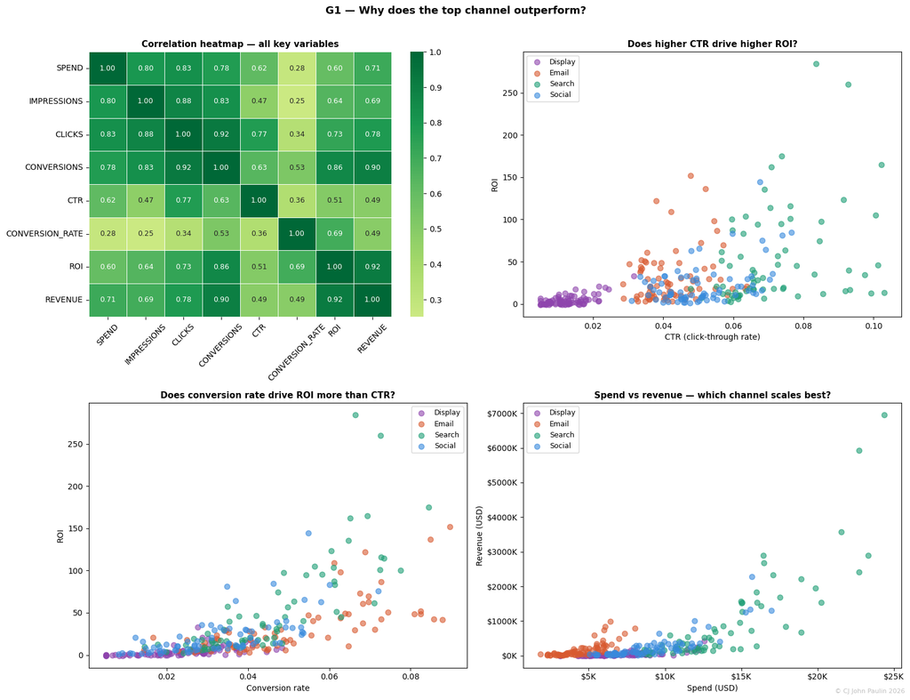

```
________________________________________________________________________

=== Channel Performance Decomposition ===

------------------------------------------------------------------------
         avg_ctr  avg_conversion_rate  avg_roi   avg_spend  avg_revenue  \
CHANNEL
Display   0.0126               0.0237   4.3719   7197.2514   46236.8453
Email     0.0424               0.0495  31.2588   4547.1029  172604.6582
Search    0.0716               0.0456  53.7597  13725.7518  930217.5560
Social    0.0509               0.0330  23.2133   9039.4112  267651.1872

         campaign_count
CHANNEL
Display              81
Email                77
Search               68
Social               74
________________________________________________________________________

=== CTR rank vs Conversion Rate rank vs ROI rank ===
         CTR_rank  CVR_rank  ROI_rank  Spend_rank
CHANNEL
Display         4         4         4           3
Email           3         1         2           4
Search          1         2         1           1
Social          2         3         3           2
```

| Correlation | Strength |
| --- | --- |
| 0.00–0.19 | Very weak |
| 0.20–0.39 | Weak |
| 0.40–0.59 | Moderate |
| 0.60–0.79 | Strong |
| 0.80–1.00 | Very strong |

### Core finding

Search dominates because it wins at both ends of the funnel — it attracts the most clicks (CTR rank 1) and converts them at near-top efficiency (conversion rate rank 2), resulting in the highest ROI (rank 1) in the portfolio. Search's dominance is structural, not accidental.

### The most actionable finding — Email's hidden efficiency

Email ranks last in spend (rank 4) but first in conversion rate (rank 1) and second in ROI (rank 2). This means the highest-converting channel in the portfolio is receiving the smallest budget. Every dollar shifted from Display to Email is likely to generate a better return — Email converts clicks to purchases more reliably than any other channel but is being systematically underfunded.

### What ROI actually depends on

The strongest correlation with ROI across all campaigns is revenue (r = 0.92), confirming that high-ROI campaigns are genuinely high-revenue campaigns — not low-cost illusions. ROI gains are real and scale with actual business outcomes.

### This means...

Search earns its budget through funnel-wide dominance, but Email is the portfolio's most underfunded asset — it converts better than any channel yet receives the least investment, making it the single highest-priority reallocation opportunity in the dataset.

### Some Search Channel campagign scales best that for higher spending theres higher revenue.

# 2. Are seasonal peaks driven by spend increases or genuine audience engagement lifts?

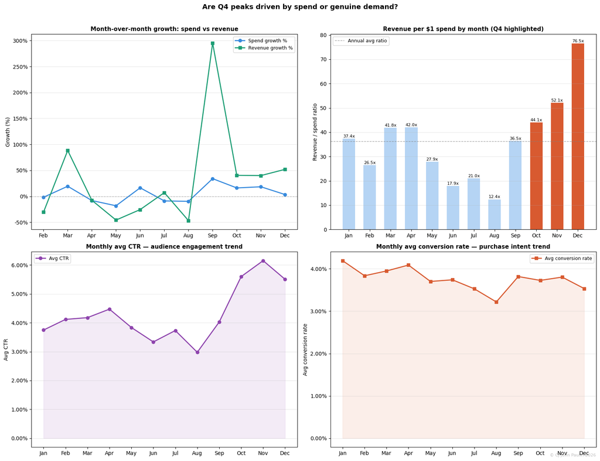

```
________________________________________________________________________
=== Monthly Revenue/Spend Ratio ===
MONTH_LABEL  total_spend  total_revenue  revenue_spend_ratio
        Jan    186866.44     6980551.48                37.36
        Feb    183643.31     4866644.10                26.50
        Mar    219336.22     9165949.10                41.79
        Apr    201583.21     8472400.48                42.03
        May    165024.97     4601659.15                27.88
        Jun    192125.50     3428683.54                17.85
        Jul    175216.96     3673526.05                20.97
        Aug    158327.42     1958149.78                12.37
        Sep    212277.31     7739603.65                36.46
        Oct    246669.13    10868057.82                44.06
        Nov    292123.33    15215275.24                52.09
        Dec    302178.03    23126224.42                76.53

________________________________________________________________________
=== Q4 vs Non-Q4 Comparison ===
         avg_spend  avg_revenue  avg_roi  avg_ctr  avg_conversion_rate
Non-Q4   7530.6726  226165.1881  22.2957   0.0382               0.0378
Q4      11212.9399  656127.4331  41.5728   0.0575               0.0369

________________________________________________________________________
=== Month-over-Month Growth Rates ===
MONTH_LABEL  spend_growth  revenue_growth
        Jan           NaN             NaN
        Feb         -1.72          -30.28
        Mar         19.44           88.34
        Apr         -8.09           -7.57
        May        -18.14          -45.69
        Jun         16.42          -25.49
        Jul         -8.80            7.14
        Aug         -9.64          -46.70
        Sep         34.07          295.25
        Oct         16.20           40.42
        Nov         18.43           40.00
        Dec          3.44           51.99
```

# 3. Which channel audience segment combination is being under-invested in?

```
________________________________________________________________________
=== Avg ROI by Channel × Audience Segment ===
AUDIENCE_SEGMENT  Professionals  Seniors  Young Adults
CHANNEL
Display                    8.50     0.25          1.31
Email                     63.33    12.11         18.60
Search                   119.85    13.81         29.80
Social                    49.65     8.70         18.90

________________________________________________________________________
=== Avg Spend by Channel × Audience Segment ===
AUDIENCE_SEGMENT  Professionals   Seniors  Young Adults
CHANNEL
Display                 8470.72   5688.06       6402.36
Email                   5752.79   3787.76       4123.15
Search                 17823.34  11034.39      12436.71
Social                 11315.50   7172.91       9221.59
```

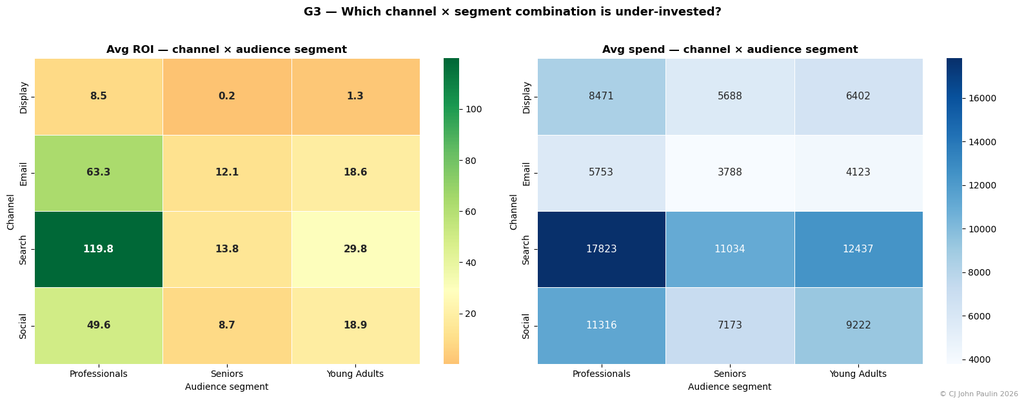

```
________________________________________________________________________
=== ROI vs Spend Gap Analysis ===
CHANNEL       SEGMENT  avg_roi  avg_spend  roi_rank  spend_rank  opportunity_gap
  Email Professionals    63.33    5752.79         2           9                7
  Email  Young Adults    18.60    4123.15         6          11                5
  Email       Seniors    12.11    3787.76         8          12                4
 Search Professionals   119.85   17823.34         1           1                0
 Social Professionals    49.65   11315.50         3           3                0
 Social  Young Adults    18.90    9221.59         5           5                0
Display       Seniors     0.25    5688.06        12          10               -2
 Search  Young Adults    29.80   12436.71         4           2               -2
 Social       Seniors     8.70    7172.91         9           7               -2
Display  Young Adults     1.31    6402.36        11           8               -3
 Search       Seniors    13.81   11034.39         7           4               -3
Display Professionals     8.50    8470.72        10           6               -4

--- Positive opportunity_gap = high ROI but low spend = underinvested ---
```

## Heatmap verdict

Comparing ROI and spend heatmaps side by side reveals a clear pattern — the highest-returning combinations are not receiving proportional investment, while the lowest-returning combinations continue to consume meaningful budget.

## Full ROI matrix by channel × segment

[output not shown]

✦ Best performing combination — well funded, protect this budget ↑ Highest opportunity gap — high ROI, systematically underfunded

## The three strategic findings

**1. Email × Professionals — the portfolio's biggest missed opportunity** ROI of 63.3 with below-average spend makes this the most under-invested combination in the dataset. Email already leads all channels in conversion rate (G1 finding) and Professionals are the cheapest segment to convert at $20 per conversion (D3 finding). Together they compound into the highest-efficiency pairing that is being systematically ignored.

**2. Search × Professionals — the core asset** ROI of 119.8 is the highest single combination in the entire matrix and it is already well-funded. This combination should be protected at all costs — it is the revenue engine of the portfolio. Any budget cuts should come from elsewhere.

**3. Display — a universal underperformer** Display produces ROI between 0.25 and 8.5 across all three segments. There is no combination where Display justifies its spend. It is the only channel that fails across every audience simultaneously, making it the clearest reallocation target in the portfolio.

## Segment efficiency summary

- Professionals respond strongly across Search and Email — high intent, high conversion, lowest cost per conversion
- Young Adults respond best to Search and Social — engaged at the click level but require the right channel
- Seniors show weak ROI across all channels (≤13.8) — current targeting and messaging is not resonating with this segment

## This means...

The business is over-investing in Display across all segments and under-investing in Email × Professionals — the combination with the second-highest ROI in the portfolio. Reallocating even a portion of Display budget to Email campaigns targeting Professionals represents the highest-confidence budget improvement available in this dataset.